# Problem Set 10

Eric Zhou

2022-10-12

## **Problem 1**

#### **Part a**: Nominal, names of what States, assuming we want names of States and there’s no defined order

#### **Part b**: Discrete, assuming that money is not continuous since you can’t really have half a cent so the number of cents has to be a discrete number

#### **Part c**: Discrete, assuming that you would just round to the nearest gun or nearest thousand guns or whatever because you wouldn’t really count gun parts as a fraction of a gun

#### **Part d**: Discrete, can’t have part of a human so it has to be a number

#### **Part e**: Binary, assuming that we are only categorizing into True, there is availability, or False, there is no availability

#### **Part f**: Discrete, assuming that money is not continuous since you can’t really have half a cent so the number of cents has to be a discrete number

## **Problem 2**

```r
section1 <- c(92, 88, 100, 96, 80, 82, 85, 93, 81, 95, 84, 92, 93, 90, 92)
section2 <- c(92, 90, 99, 95, 78, 81, 83, 94, 75, 98, 94, 96, 94, 89)
```

#### **Part a**: Section 1 has 89.53333 (mean), 92 (median), and 92(mode), Section 2 has 89.85714 (mean), 93 (median), and 94 (mode)

```r
mean(section1)
```

```
## [1] 89.53333
```

```r
mean(section2)
```

```
## [1] 89.85714
```

```r
median(section1)
```

```
## [1] 92
```

```r
median(section2)
```

```
## [1] 93
```

```r
table(section1) # Mode is 92
```

```
## section1
##  80  81  82  84  85  88  90  92  93  95  96 100
##   1   1   1   1   1   1   1   3   2   1   1   1
```

```r
table(section2) # Mode is 94
```

```
## section2
## 75 78 81 83 89 90 92 94 95 96 98 99
##  1  1  1  1  1  1  1  3  1  1  1  1
```

#### **Part b**: Section 1 has 15, Section 2 has 14

```r
length(section1)
```

```
## [1] 15
```

```r
length(section2)
```

```
## [1] 14
```

#### **Part c**:

```r
sort(section1)
```

```
##  [1]  80  81  82  84  85  88  90  92  92  92  93  93  95  96 100
```

```r
sort(section2)
```

```
##  [1] 75 78 81 83 89 90 92 94 94 94 95 96 98 99
```

#### **Part d**: Changing freq changes the unity of the y-axis from frequency to density

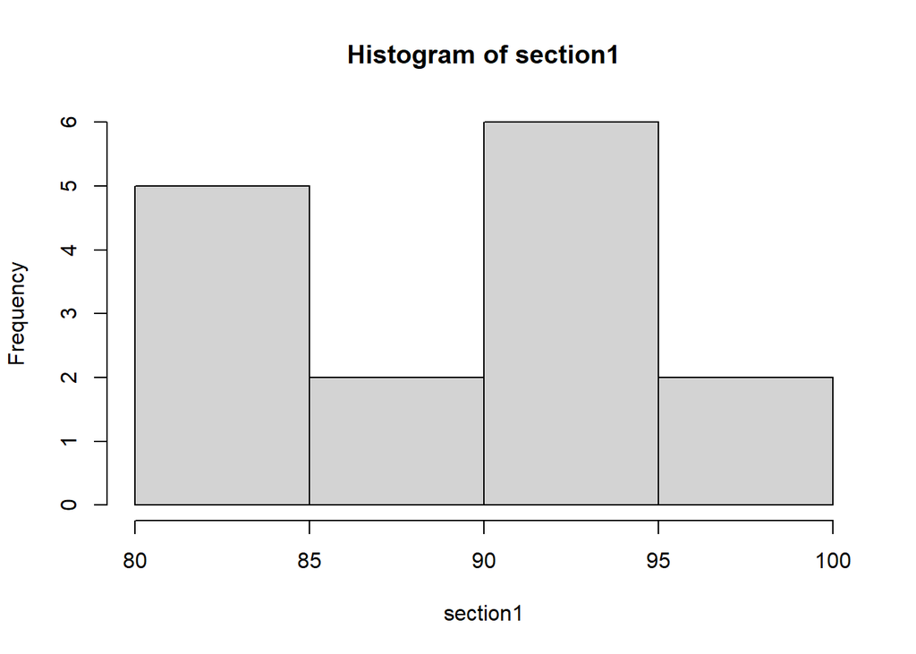

```r
hist(section1, freq=TRUE)
```

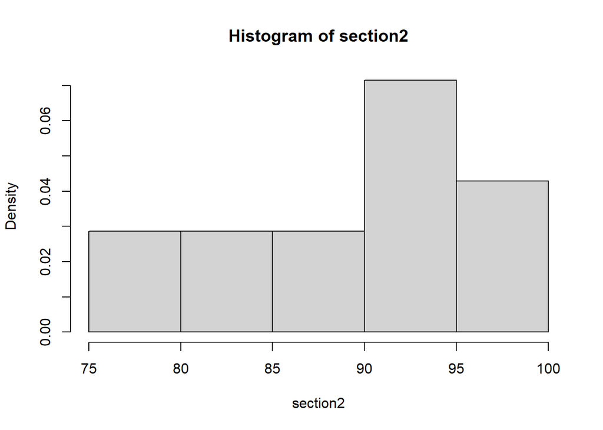

```r
hist(section2, freq=FALSE)
```

#### **Part e**: Section 2 has higher mean and median scores so I would say they did better.

#### **Part f**: It is the exact same

```r
sum(section1)/length(section1)
```

```
## [1] 89.53333
```

## **Problem 3**

```r
temps <- c(71, 71, 69, 71, 69, 72, 71, 70, 70, 71, 82, 76, 74, 73, 74, 82, 82, 77, 80, 83, 83, 81, 72, 72, 71, 72, 72, 71, 72, 72, 73)
```

#### **Part a**: It plotted the index of the temperature in the list with the temperature value

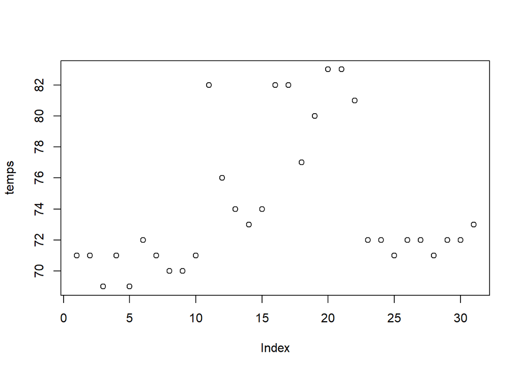

```r
plot(temps)
```

#### **Part b**: 31

```r
length(temps)
```

```
## [1] 31
```

#### **Part c**:

```r
li <- seq(1:length(temps))
```

#### **Part d**: The same because the index values are also start from 1 and increase, same as the Day number

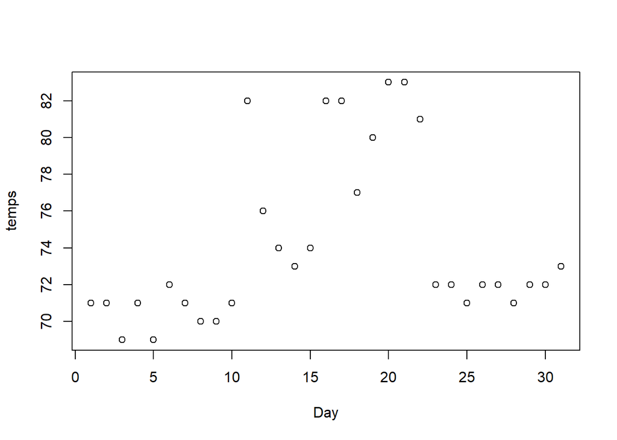

```r
plot(x=li, y=temps, xlab="Day")
```

#### **Part e**: I think the line plot is a bit clearer because it shows the connections between points

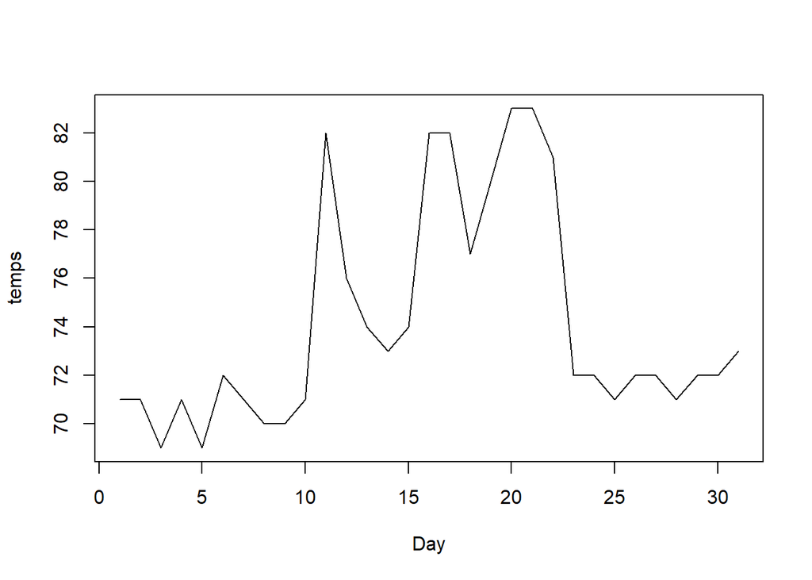

```r
plot(x=li, y=temps, xlab="Day", type='l')
```

## **Problem 4**

```r
section1[5] <- 83
```

#### **Part a**: Mean went from 89.53333 to 89.733333, Median remained at 92

```r
mean(section1)
```

```
## [1] 89.73333
```

```r
median(section1)
```

```
## [1] 92
```